# Single seed microbiota: assembly and transmission from parent plant to seedling

Chesneau et al., 2021

21/05/2021

# Before you start

This script has been made on R 4.0.0 (and Rstudio 1.2.5019)

```r
R.version
```

```
##                _
## platform       x86_64-w64-mingw32
## arch           x86_64
## os             mingw32
## system         x86_64, mingw32
## status
## major          4
## minor          0.0
## year           2020
## month          04
## day            24
## svn rev        78286
## language       R
## version.string R version 4.0.0 (2020-04-24)
## nickname       Arbor Day
```

```r
library(ggplot2)
#Load theme set
theme_set(theme_bw())
```

# Data information

**Project:** ANR SEEDS

**Experiment 1:** “Culture-based enrichment of seed-borne bacteria”

**Factors first dataset :**

- Plant species : bean (*Phaseolus vulgaris*) and radish (*Raphanus sativus*)
- Habitats sampled : Seed lots
- DNA extraction : MN Food directly after seed soaking (DNA) or after enrichment on TSA10% (CFU)
- 1 sequencing run (MiSeq v2 - 500 cycles )

# 1- Sequence analyses

## 1.1 - Remove primers with cutadapt v1.15

```
for i in `cat group`; do cutadapt --discard-untrimmed -o $i.gyrB.R1.fq -p $i.gyrB.R2.fq -g MGNCCNGSNATGTAYATHGG -G ACNCCRTGNARDCCDCCNGA -e 0.1  -O 20 $i*L001_R1_001.fastq.gz $i*_L001_R2_001.fastq.gz; done
```

## 1.2- Convert fastq to ASV table (dada2)

To save computing time, the code is not evaluated in the version of the document and the results are not included.

# 2 - Filtering data

## 2.1 - Construct phyloseq objects

## 2.2 - ASVs filtering

- Filtered ASV based on taxonomy
- Rename ASV sequences
- Subset Samples (remove sample with less than 1000 counts)

## 2.3 - Phylogenetic tree

# 3 - Compare community profiles estimated with DNA or CFU

## 3.1 - Assess sequencing depth

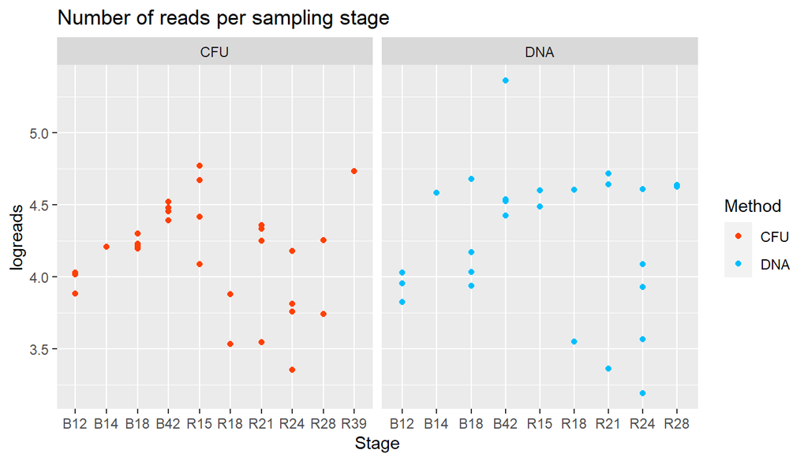

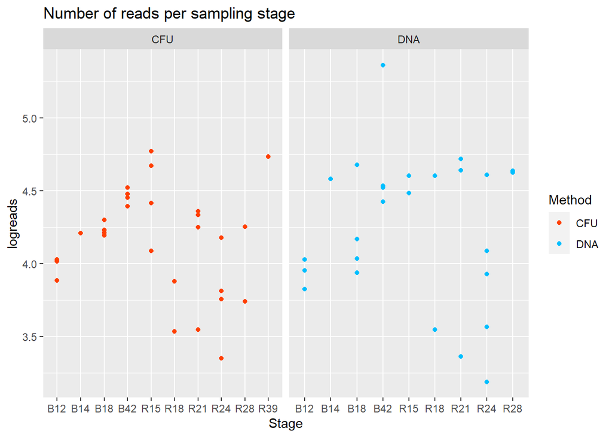

We next performed rarefaction curves

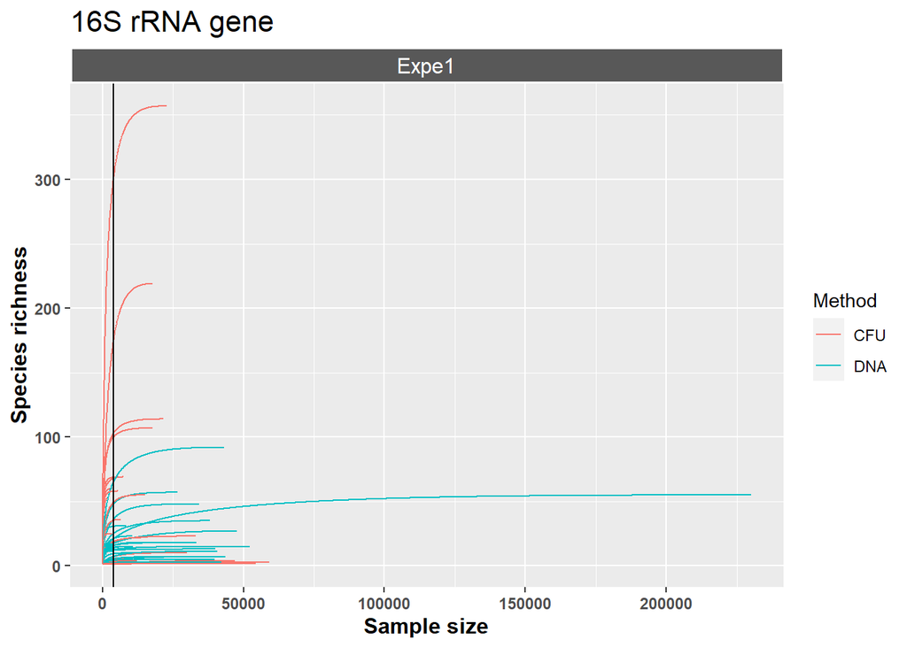

## 3.2 - Select samples that have been characterized with DNA and CFU-based approaches

- Overall 24 samples have been characterized with DNA and CFU-based approaches.

## 3.3 - UpSet

- Compare presence of specific ASVs in CFU and DNA approach and shared ASVs between approaches.

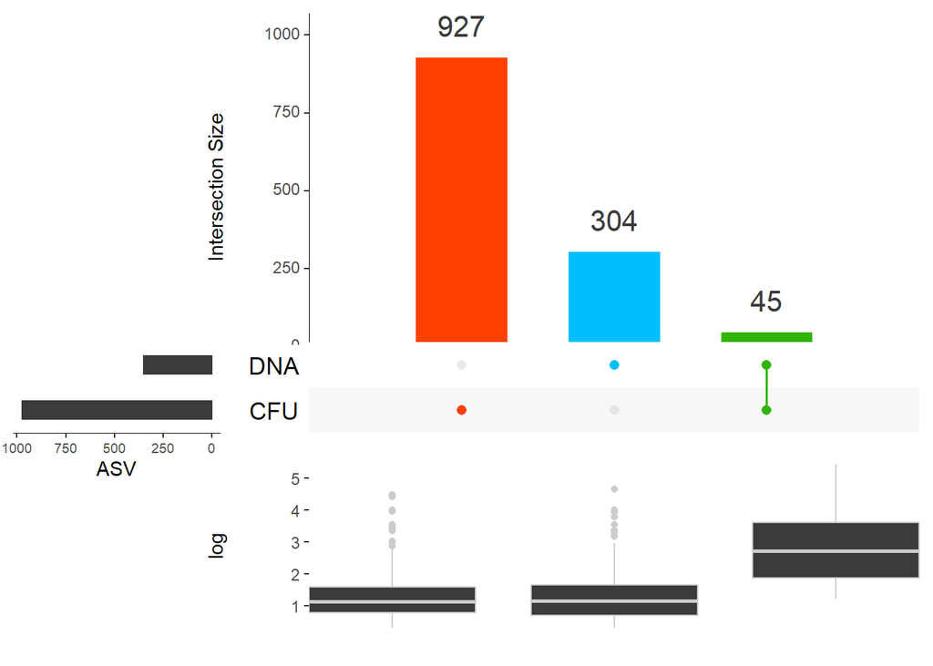

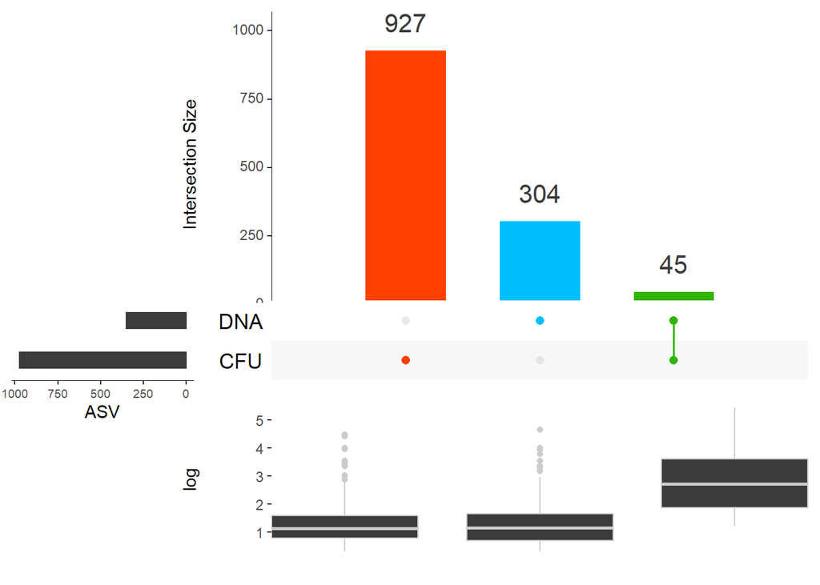

## 3.4 - Rank abundance curve

We estimated rank abundance curves of taxa associated with seeds.

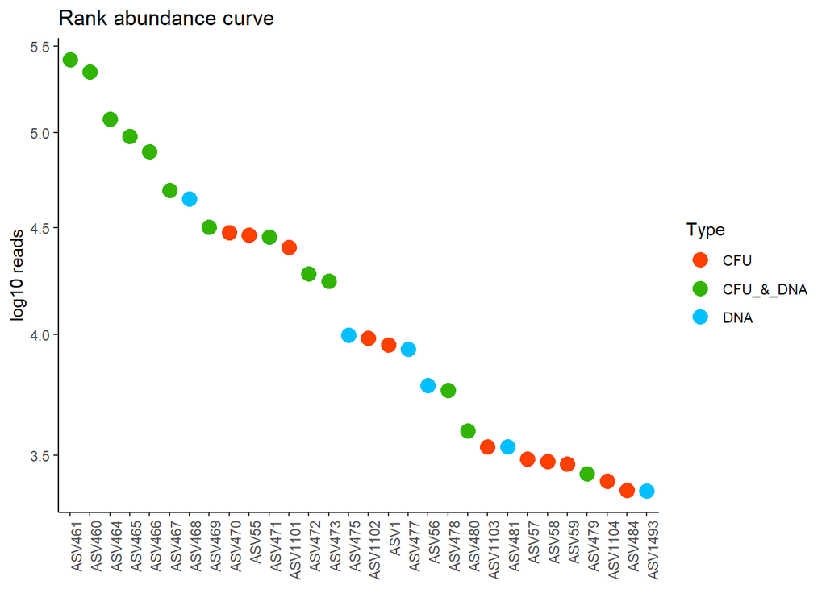

```
##         ASV      Type Abundance      log
## 770  ASV461 CFU_&_DNA    262241 5.418701
## 769  ASV460 CFU_&_DNA    221340 5.345060
## 772  ASV464 CFU_&_DNA    118697 5.074440
## 773  ASV465 CFU_&_DNA     94890 4.977220
## 774  ASV466 CFU_&_DNA     78712 4.896041
## 775  ASV467 CFU_&_DNA     49041 4.690559
## 776  ASV468       DNA     44344 4.646835
## 777  ASV469 CFU_&_DNA     31848 4.503082
## 779  ASV470       CFU     29981 4.476846
## 856   ASV55       CFU     29006 4.462488
## 780  ASV471 CFU_&_DNA     28454 4.454143
## 93  ASV1101       CFU     25347 4.403927
## 781  ASV472 CFU_&_DNA     18918 4.276875
## 782  ASV473 CFU_&_DNA     17437 4.241472
```

[output cut: 16 more lines]

## 3.5 - Overview of taxonomic composition

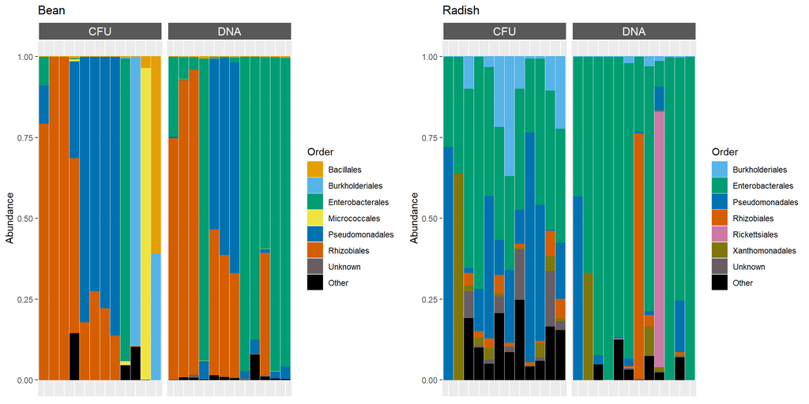

## 3.6 - Beta-diversity analyses

We performed a log(1+x) transformation for limiting the impact of unequal sequencing depth.

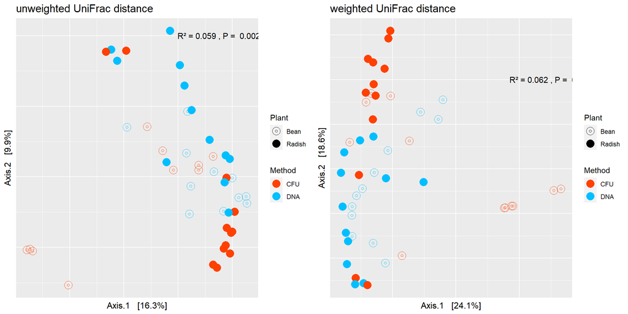

## 3.7 - Phylogenetic tree

Display phylogentic tree

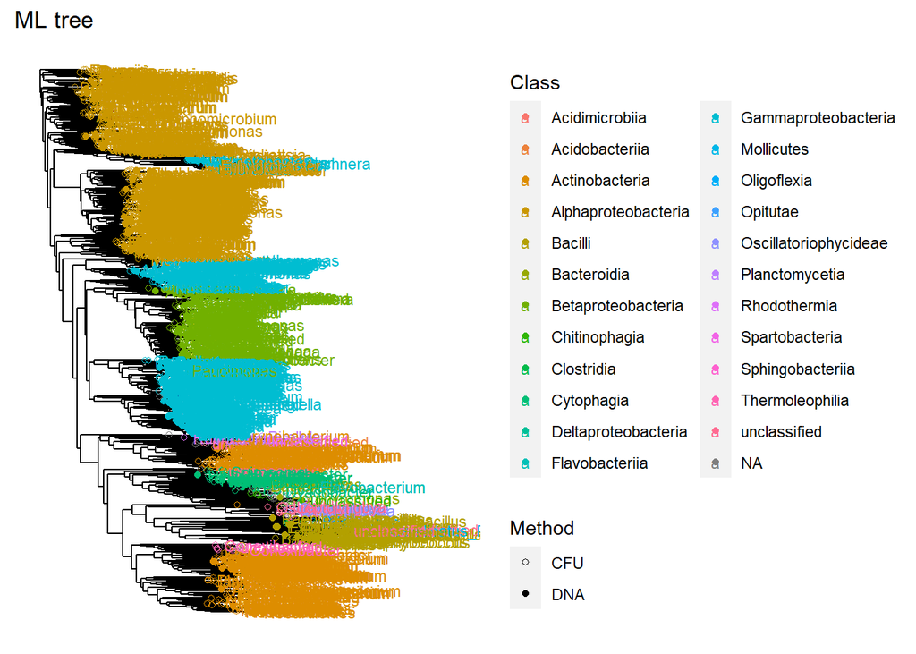

Export newick formatted tree for iTol

# End of script

Chesneau et al., 2021  
title: “Single seed microbiota: assembly and transmission from parent plant to seedling”